# Optimal Treatment Analysis

## Outcome Variable

**Outcome Variable:** whz

## Predictor Variables

**Intervention Variable:** birthlen

**Adjustment Set:**

- arm
- sex
- W_mage
- meducyrs
- feducyrs
- vagbrth
- single
- brthmon
- W_parity
- delta_W_mage
- delta_meducyrs
- delta_feducyrs
- delta_vagbrth
- delta_single
- delta_brthmon
- delta_W_parity

## Stratifying Variables

The analysis was stratified on these variable(s):

- agecat
- studyid
- country

## Data Summary

| agecat | studyid | country | birthlen | n_cell | n |
| --- | --- | --- | --- | --- | --- |
| Birth | ki0047075b-MAL-ED | BANGLADESH | >=50 cm | 29 | 241 |
| Birth | ki0047075b-MAL-ED | BANGLADESH | <48 cm | 128 | 241 |
| Birth | ki0047075b-MAL-ED | BANGLADESH | [48-50) cm | 84 | 241 |
| Birth | ki0047075b-MAL-ED | BRAZIL | >=50 cm | 34 | 183 |
| Birth | ki0047075b-MAL-ED | BRAZIL | <48 cm | 73 | 183 |
| Birth | ki0047075b-MAL-ED | BRAZIL | [48-50) cm | 76 | 183 |
| Birth | ki0047075b-MAL-ED | INDIA | >=50 cm | 25 | 203 |
| Birth | ki0047075b-MAL-ED | INDIA | <48 cm | 104 | 203 |
| Birth | ki0047075b-MAL-ED | INDIA | [48-50) cm | 74 | 203 |
| Birth | ki0047075b-MAL-ED | NEPAL | >=50 cm | 38 | 168 |
| Birth | ki0047075b-MAL-ED | NEPAL | <48 cm | 64 | 168 |
| Birth | ki0047075b-MAL-ED | NEPAL | [48-50) cm | 66 | 168 |
| Birth | ki0047075b-MAL-ED | PERU | >=50 cm | 34 | 279 |
| Birth | ki0047075b-MAL-ED | PERU | <48 cm | 134 | 279 |
| Birth | ki0047075b-MAL-ED | PERU | [48-50) cm | 111 | 279 |
| Birth | ki0047075b-MAL-ED | SOUTH AFRICA | >=50 cm | 46 | 258 |
| Birth | ki0047075b-MAL-ED | SOUTH AFRICA | <48 cm | 109 | 258 |
| Birth | ki0047075b-MAL-ED | SOUTH AFRICA | [48-50) cm | 103 | 258 |
| Birth | ki0047075b-MAL-ED | TANZANIA, UNITED REPUBLIC OF | >=50 cm | 15 | 118 |
| Birth | ki0047075b-MAL-ED | TANZANIA, UNITED REPUBLIC OF | <48 cm | 52 | 118 |
| Birth | ki0047075b-MAL-ED | TANZANIA, UNITED REPUBLIC OF | [48-50) cm | 51 | 118 |
| Birth | ki1000108-CMC-V-BCS-2002 | INDIA | >=50 cm | 12 | 84 |
| Birth | ki1000108-CMC-V-BCS-2002 | INDIA | <48 cm | 32 | 84 |
| Birth | ki1000108-CMC-V-BCS-2002 | INDIA | [48-50) cm | 40 | 84 |
| Birth | ki1000108-IRC | INDIA | >=50 cm | 120 | 343 |
| Birth | ki1000108-IRC | INDIA | <48 cm | 87 | 343 |
| Birth | ki1000108-IRC | INDIA | [48-50) cm | 136 | 343 |
| Birth | ki1000109-EE | PAKISTAN | >=50 cm | 0 | 1 |
| Birth | ki1000109-EE | PAKISTAN | <48 cm | 1 | 1 |
| Birth | ki1000109-EE | PAKISTAN | [48-50) cm | 0 | 1 |

[output cut: 201 more lines]

The following strata were considered:

- agecat: 24 months, studyid: ki0047075b-MAL-ED, country: BANGLADESH
- agecat: 24 months, studyid: ki0047075b-MAL-ED, country: BRAZIL
- agecat: 24 months, studyid: ki0047075b-MAL-ED, country: INDIA
- agecat: 24 months, studyid: ki0047075b-MAL-ED, country: NEPAL
- agecat: 24 months, studyid: ki0047075b-MAL-ED, country: PERU
- agecat: 24 months, studyid: ki0047075b-MAL-ED, country: SOUTH AFRICA
- agecat: 24 months, studyid: ki0047075b-MAL-ED, country: TANZANIA, UNITED REPUBLIC OF
- agecat: 24 months, studyid: ki1000108-CMC-V-BCS-2002, country: INDIA
- agecat: 24 months, studyid: ki1000108-IRC, country: INDIA
- agecat: 24 months, studyid: ki1017093-NIH-Birth, country: BANGLADESH
- agecat: 24 months, studyid: ki1017093b-PROVIDE, country: BANGLADESH
- agecat: 24 months, studyid: ki1017093c-NIH-Crypto, country: BANGLADESH
- agecat: 24 months, studyid: ki1101329-Keneba, country: GAMBIA
- agecat: 24 months, studyid: ki1114097-CMIN, country: BANGLADESH
- agecat: 24 months, studyid: ki1114097-CMIN, country: PERU
- agecat: 24 months, studyid: ki1114097-CONTENT, country: PERU
- agecat: 24 months, studyid: ki1119695-PROBIT, country: BELARUS
- agecat: 24 months, studyid: ki1126311-ZVITAMBO, country: ZIMBABWE
- agecat: 24 months, studyid: ki1135781-COHORTS, country: GUATEMALA
- agecat: 24 months, studyid: ki1135781-COHORTS, country: INDIA
- agecat: 24 months, studyid: ki1135781-COHORTS, country: PHILIPPINES
- agecat: 24 months, studyid: kiGH5241-JiVitA-3, country: BANGLADESH
- agecat: 24 months, studyid: kiGH5241-JiVitA-4, country: BANGLADESH
- agecat: 6 months, studyid: ki0047075b-MAL-ED, country: BANGLADESH
- agecat: 6 months, studyid: ki0047075b-MAL-ED, country: BRAZIL
- agecat: 6 months, studyid: ki0047075b-MAL-ED, country: INDIA
- agecat: 6 months, studyid: ki0047075b-MAL-ED, country: NEPAL
- agecat: 6 months, studyid: ki0047075b-MAL-ED, country: PERU
- agecat: 6 months, studyid: ki0047075b-MAL-ED, country: SOUTH AFRICA
- agecat: 6 months, studyid: ki0047075b-MAL-ED, country: TANZANIA, UNITED REPUBLIC OF
- agecat: 6 months, studyid: ki1000108-CMC-V-BCS-2002, country: INDIA
- agecat: 6 months, studyid: ki1000108-IRC, country: INDIA
- agecat: 6 months, studyid: ki1000109-EE, country: PAKISTAN
- agecat: 6 months, studyid: ki1000109-ResPak, country: PAKISTAN
- agecat: 6 months, studyid: ki1000304b-SAS-CompFeed, country: INDIA
- agecat: 6 months, studyid: ki1017093-NIH-Birth, country: BANGLADESH
- agecat: 6 months, studyid: ki1017093b-PROVIDE, country: BANGLADESH
- agecat: 6 months, studyid: ki1017093c-NIH-Crypto, country: BANGLADESH
- agecat: 6 months, studyid: ki1101329-Keneba, country: GAMBIA
- agecat: 6 months, studyid: ki1114097-CMIN, country: BANGLADESH
- agecat: 6 months, studyid: ki1114097-CMIN, country: BRAZIL
- agecat: 6 months, studyid: ki1114097-CMIN, country: GUINEA-BISSAU
- agecat: 6 months, studyid: ki1114097-CMIN, country: PERU
- agecat: 6 months, studyid: ki1114097-CONTENT, country: PERU
- agecat: 6 months, studyid: ki1119695-PROBIT, country: BELARUS
- agecat: 6 months, studyid: ki1126311-ZVITAMBO, country: ZIMBABWE
- agecat: 6 months, studyid: ki1135781-COHORTS, country: GUATEMALA
- agecat: 6 months, studyid: ki1135781-COHORTS, country: INDIA
- agecat: 6 months, studyid: ki1135781-COHORTS, country: PHILIPPINES
- agecat: 6 months, studyid: kiGH5241-JiVitA-3, country: BANGLADESH
- agecat: 6 months, studyid: kiGH5241-JiVitA-4, country: BANGLADESH
- agecat: Birth, studyid: ki0047075b-MAL-ED, country: BANGLADESH
- agecat: Birth, studyid: ki0047075b-MAL-ED, country: BRAZIL
- agecat: Birth, studyid: ki0047075b-MAL-ED, country: INDIA
- agecat: Birth, studyid: ki0047075b-MAL-ED, country: NEPAL
- agecat: Birth, studyid: ki0047075b-MAL-ED, country: PERU
- agecat: Birth, studyid: ki0047075b-MAL-ED, country: SOUTH AFRICA
- agecat: Birth, studyid: ki0047075b-MAL-ED, country: TANZANIA, UNITED REPUBLIC OF
- agecat: Birth, studyid: ki1000108-CMC-V-BCS-2002, country: INDIA
- agecat: Birth, studyid: ki1000108-IRC, country: INDIA
- agecat: Birth, studyid: ki1000109-EE, country: PAKISTAN
- agecat: Birth, studyid: ki1000109-ResPak, country: PAKISTAN
- agecat: Birth, studyid: ki1000304b-SAS-CompFeed, country: INDIA
- agecat: Birth, studyid: ki1017093-NIH-Birth, country: BANGLADESH
- agecat: Birth, studyid: ki1017093c-NIH-Crypto, country: BANGLADESH
- agecat: Birth, studyid: ki1101329-Keneba, country: GAMBIA
- agecat: Birth, studyid: ki1114097-CMIN, country: BANGLADESH
- agecat: Birth, studyid: ki1114097-CMIN, country: BRAZIL
- agecat: Birth, studyid: ki1114097-CMIN, country: PERU
- agecat: Birth, studyid: ki1114097-CONTENT, country: PERU
- agecat: Birth, studyid: ki1119695-PROBIT, country: BELARUS
- agecat: Birth, studyid: ki1126311-ZVITAMBO, country: ZIMBABWE
- agecat: Birth, studyid: ki1135781-COHORTS, country: GUATEMALA
- agecat: Birth, studyid: ki1135781-COHORTS, country: INDIA
- agecat: Birth, studyid: ki1135781-COHORTS, country: PHILIPPINES
- agecat: Birth, studyid: kiGH5241-JiVitA-3, country: BANGLADESH
- agecat: Birth, studyid: kiGH5241-JiVitA-4, country: BANGLADESH

### Dropped Strata

Some strata were dropped due to rare outcomes:

- agecat: Birth, studyid: ki1000109-EE, country: PAKISTAN
- agecat: Birth, studyid: ki1000109-ResPak, country: PAKISTAN
- agecat: Birth, studyid: ki1017093c-NIH-Crypto, country: BANGLADESH
- agecat: Birth, studyid: ki1114097-CMIN, country: BANGLADESH
- agecat: Birth, studyid: ki1114097-CMIN, country: PERU
- agecat: Birth, studyid: ki1114097-CONTENT, country: PERU
- agecat: 6 months, studyid: ki1000109-ResPak, country: PAKISTAN
- agecat: 6 months, studyid: ki1114097-CMIN, country: BANGLADESH
- agecat: 6 months, studyid: ki1114097-CMIN, country: GUINEA-BISSAU
- agecat: 6 months, studyid: ki1114097-CMIN, country: PERU
- agecat: 6 months, studyid: ki1114097-CONTENT, country: PERU
- agecat: 24 months, studyid: ki1114097-CMIN, country: BANGLADESH
- agecat: 24 months, studyid: ki1114097-CMIN, country: PERU
- agecat: 24 months, studyid: ki1114097-CONTENT, country: PERU

## Methods Detail

We’re interested in the causal parameters $E[Y_a]$ for all values of $a \in \mathcal{A}$. These parameters represent the mean outcome if, possibly contrary to fact, we intervened to set all units to have $A=a$. Under the randomization and positivity assumptions, these are identified by the statistical parameters $\psi_a=E_W[E_{Y|A,W}(Y|A=a,W)]$. In addition, we’re interested in the mean of $Y$, $E[Y]$ under no intervention (the observed mean). We will estimate these parameters by using SuperLearner to fit the relevant likelihood factors – $E_{Y|A,W}(Y|A=a,W)$ and $p(A=a|W)$, and then updating our likelihood fit using a joint TMLE.

For unadjusted analyses ($W=\{\}$), initial likelihoods were estimated using Lrnr_glm to estimate the simple $E(Y|A)$ and Lrnr_mean to estimate $p(A)$. For adjusted analyses, a small library containing Lrnr_glmnet, Lrnr_xgboost, and Lrnr_mean was used.

# Results Detail

## Results Plots

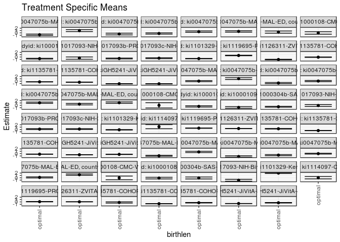

## Results Table

### Parameter: TSM

| agecat | studyid | country | intervention_level | baseline_level | estimate | ci_lower | ci_upper |
| --- | --- | --- | --- | --- | --- | --- | --- |
| Birth | ki0047075b-MAL-ED | BANGLADESH | optimal | observed | -0.9133817 | -1.1071612 | -0.7196023 |
| Birth | ki0047075b-MAL-ED | BRAZIL | optimal | observed | 0.7234494 | 0.4598308 | 0.9870679 |
| Birth | ki0047075b-MAL-ED | INDIA | optimal | observed | -1.2354522 | -1.5305596 | -0.9403449 |
| Birth | ki0047075b-MAL-ED | NEPAL | optimal | observed | -0.6463407 | -0.8893560 | -0.4033253 |
| Birth | ki0047075b-MAL-ED | PERU | optimal | observed | -0.0105772 | -0.1803562 | 0.1592018 |
| Birth | ki0047075b-MAL-ED | SOUTH AFRICA | optimal | observed | 0.1547267 | -0.0762552 | 0.3857086 |
| Birth | ki0047075b-MAL-ED | TANZANIA, UNITED REPUBLIC OF | optimal | observed | 1.3133951 | 1.0365611 | 1.5902291 |
| Birth | ki1000108-CMC-V-BCS-2002 | INDIA | optimal | observed | -0.0584245 | -0.8433845 | 0.7265356 |
| Birth | ki1000108-IRC | INDIA | optimal | observed | -0.1335397 | -0.4899492 | 0.2228698 |
| Birth | ki1000304b-SAS-CompFeed | INDIA | optimal | observed | -0.0805602 | -0.5013385 | 0.3402180 |
| Birth | ki1017093-NIH-Birth | BANGLADESH | optimal | observed | -1.0693097 | -1.4937191 | -0.6449002 |
| Birth | ki1101329-Keneba | GAMBIA | optimal | observed | 1.9936613 | 1.8233380 | 2.1639847 |
| Birth | ki1114097-CMIN | BRAZIL | optimal | observed | 0.0308762 | -0.4644790 | 0.5262313 |
| Birth | ki1119695-PROBIT | BELARUS | optimal | observed | 0.0943450 | 0.0089461 | 0.1797439 |
| Birth | ki1126311-ZVITAMBO | ZIMBABWE | optimal | observed | 0.0472975 | -0.0023397 | 0.0969346 |
| Birth | ki1135781-COHORTS | GUATEMALA | optimal | observed | -0.2435768 | -0.5038999 | 0.0167463 |
| Birth | ki1135781-COHORTS | INDIA | optimal | observed | -0.7757369 | -0.8266306 | -0.7248431 |
| Birth | ki1135781-COHORTS | PHILIPPINES | optimal | observed | -0.3528550 | -0.4570530 | -0.2486569 |
| Birth | kiGH5241-JiVitA-3 | BANGLADESH | optimal | observed | -0.6908940 | -0.7198152 | -0.6619727 |
| Birth | kiGH5241-JiVitA-4 | BANGLADESH | optimal | observed | -0.3675058 | -0.4792694 | -0.2557422 |
| 6 months | ki0047075b-MAL-ED | BANGLADESH | optimal | observed | 0.0315677 | -0.2039102 | 0.2670456 |
| 6 months | ki0047075b-MAL-ED | BRAZIL | optimal | observed | 1.0918118 | 0.7116602 | 1.4719634 |
| 6 months | ki0047075b-MAL-ED | INDIA | optimal | observed | -0.7894793 | -1.0337298 | -0.5452287 |
| 6 months | ki0047075b-MAL-ED | NEPAL | optimal | observed | 0.0519418 | -0.1983999 | 0.3022835 |
| 6 months | ki0047075b-MAL-ED | PERU | optimal | observed | 1.0939754 | 0.8184023 | 1.3695486 |
| 6 months | ki0047075b-MAL-ED | SOUTH AFRICA | optimal | observed | 0.4940047 | 0.1847836 | 0.8032257 |
| 6 months | ki0047075b-MAL-ED | TANZANIA, UNITED REPUBLIC OF | optimal | observed | 1.1288685 | 0.8149718 | 1.4427651 |
| 6 months | ki1000108-CMC-V-BCS-2002 | INDIA | optimal | observed | -0.0134915 | -1.1492576 | 1.1222746 |
| 6 months | ki1000108-IRC | INDIA | optimal | observed | -0.4555216 | -0.7263773 | -0.1846659 |
| 6 months | ki1000109-EE | PAKISTAN | optimal | observed | -0.9094629 | -1.2598128 | -0.5591130 |
| 6 months | ki1000304b-SAS-CompFeed | INDIA | optimal | observed | -0.6073841 | -0.7732246 | -0.4415437 |
| 6 months | ki1017093-NIH-Birth | BANGLADESH | optimal | observed | -0.0947831 | -0.4972731 | 0.3077070 |
| 6 months | ki1017093b-PROVIDE | BANGLADESH | optimal | observed | 0.1485155 | -0.0308833 | 0.3279143 |
| 6 months | ki1017093c-NIH-Crypto | BANGLADESH | optimal | observed | 0.1747988 | 0.0104609 | 0.3391367 |
| 6 months | ki1101329-Keneba | GAMBIA | optimal | observed | -0.1313317 | -0.2421056 | -0.0205577 |
| 6 months | ki1114097-CMIN | BRAZIL | optimal | observed | 1.1958411 | 0.3126116 | 2.0790706 |
| 6 months | ki1119695-PROBIT | BELARUS | optimal | observed | 0.5588691 | 0.4898992 | 0.6278391 |
| 6 months | ki1126311-ZVITAMBO | ZIMBABWE | optimal | observed | 0.4010465 | 0.3529439 | 0.4491491 |
| 6 months | ki1135781-COHORTS | GUATEMALA | optimal | observed | 0.3063970 | 0.1816285 | 0.4311655 |
| 6 months | ki1135781-COHORTS | INDIA | optimal | observed | -0.4727503 | -0.5314574 | -0.4140433 |
| 6 months | ki1135781-COHORTS | PHILIPPINES | optimal | observed | -0.2375239 | -0.3029956 | -0.1720522 |
| 6 months | kiGH5241-JiVitA-3 | BANGLADESH | optimal | observed | -0.4823349 | -0.5308987 | -0.4337710 |
| 6 months | kiGH5241-JiVitA-4 | BANGLADESH | optimal | observed | -0.3127878 | -0.3848138 | -0.2407617 |
| 24 months | ki0047075b-MAL-ED | BANGLADESH | optimal | observed | -0.7905541 | -1.0768714 | -0.5042368 |
| 24 months | ki0047075b-MAL-ED | BRAZIL | optimal | observed | 0.9764589 | 0.5535599 | 1.3993580 |
| 24 months | ki0047075b-MAL-ED | INDIA | optimal | observed | -0.4868656 | -0.8666254 | -0.1071059 |
| 24 months | ki0047075b-MAL-ED | NEPAL | optimal | observed | -0.2636253 | -0.5188799 | -0.0083707 |
| 24 months | ki0047075b-MAL-ED | PERU | optimal | observed | 0.5265220 | 0.2308496 | 0.8221943 |
| 24 months | ki0047075b-MAL-ED | SOUTH AFRICA | optimal | observed | 0.6297670 | 0.3344843 | 0.9250497 |
| 24 months | ki0047075b-MAL-ED | TANZANIA, UNITED REPUBLIC OF | optimal | observed | 0.3457332 | -0.1089376 | 0.8004040 |
| 24 months | ki1000108-CMC-V-BCS-2002 | INDIA | optimal | observed | -0.0206058 | -0.5397673 | 0.4985557 |
| 24 months | ki1000108-IRC | INDIA | optimal | observed | -0.6895949 | -0.8500595 | -0.5291304 |
| 24 months | ki1017093-NIH-Birth | BANGLADESH | optimal | observed | -0.4532202 | -0.9414769 | 0.0350365 |
| 24 months | ki1017093b-PROVIDE | BANGLADESH | optimal | observed | -0.6191730 | -0.7959840 | -0.4423621 |
| 24 months | ki1017093c-NIH-Crypto | BANGLADESH | optimal | observed | -0.4996018 | -0.6908164 | -0.3083873 |
| 24 months | ki1101329-Keneba | GAMBIA | optimal | observed | -0.6633220 | -0.7465080 | -0.5801360 |
| 24 months | ki1119695-PROBIT | BELARUS | optimal | observed | 0.6679487 | 0.5552620 | 0.7806354 |
| 24 months | ki1126311-ZVITAMBO | ZIMBABWE | optimal | observed | -1.0649682 | -1.1892934 | -0.9406429 |
| 24 months | ki1135781-COHORTS | GUATEMALA | optimal | observed | -0.0675710 | -0.1682436 | 0.0331016 |
| 24 months | ki1135781-COHORTS | INDIA | optimal | observed | -0.2808279 | -0.3430638 | -0.2185920 |
| 24 months | ki1135781-COHORTS | PHILIPPINES | optimal | observed | -0.4396956 | -0.4969929 | -0.3823984 |
| 24 months | kiGH5241-JiVitA-3 | BANGLADESH | optimal | observed | -1.1007794 | -1.1639328 | -1.0376260 |
| 24 months | kiGH5241-JiVitA-4 | BANGLADESH | optimal | observed | -1.1137705 | -1.1792471 | -1.0482939 |

### Parameter: E(Y)

| agecat | studyid | country | intervention_level | baseline_level | estimate | ci_lower | ci_upper |
| --- | --- | --- | --- | --- | --- | --- | --- |
| Birth | ki0047075b-MAL-ED | BANGLADESH | observed | observed | -0.9630705 | -1.0989132 | -0.8272278 |
| Birth | ki0047075b-MAL-ED | BRAZIL | observed | observed | 0.4038798 | 0.2296279 | 0.5781316 |
| Birth | ki0047075b-MAL-ED | INDIA | observed | observed | -1.0691133 | -1.2078629 | -0.9303637 |
| Birth | ki0047075b-MAL-ED | NEPAL | observed | observed | -0.9044643 | -1.0439568 | -0.7649718 |
| Birth | ki0047075b-MAL-ED | PERU | observed | observed | -0.0735842 | -0.1836203 | 0.0364518 |
| Birth | ki0047075b-MAL-ED | SOUTH AFRICA | observed | observed | -0.0562791 | -0.2000837 | 0.0875255 |
| Birth | ki0047075b-MAL-ED | TANZANIA, UNITED REPUBLIC OF | observed | observed | 0.7932203 | 0.5962220 | 0.9902187 |
| Birth | ki1000108-CMC-V-BCS-2002 | INDIA | observed | observed | -0.4259524 | -0.7275464 | -0.1243584 |
| Birth | ki1000108-IRC | INDIA | observed | observed | -1.0105831 | -1.1973019 | -0.8238643 |
| Birth | ki1000304b-SAS-CompFeed | INDIA | observed | observed | -0.2697590 | -0.5399211 | 0.0004030 |
| Birth | ki1017093-NIH-Birth | BANGLADESH | observed | observed | -1.4239286 | -1.7688028 | -1.0790544 |
| Birth | ki1101329-Keneba | GAMBIA | observed | observed | 1.7036191 | 1.6208471 | 1.7863911 |
| Birth | ki1114097-CMIN | BRAZIL | observed | observed | -0.1332432 | -0.3441055 | 0.0776190 |
| Birth | ki1119695-PROBIT | BELARUS | observed | observed | -1.1463469 | -1.3562674 | -0.9364264 |
| Birth | ki1126311-ZVITAMBO | ZIMBABWE | observed | observed | -0.5151425 | -0.5409938 | -0.4892911 |
| Birth | ki1135781-COHORTS | GUATEMALA | observed | observed | -1.0621429 | -1.1631387 | -0.9611471 |
| Birth | ki1135781-COHORTS | INDIA | observed | observed | -0.9847457 | -1.0145305 | -0.9549609 |
| Birth | ki1135781-COHORTS | PHILIPPINES | observed | observed | -0.7427251 | -0.7890855 | -0.6963647 |
| Birth | kiGH5241-JiVitA-3 | BANGLADESH | observed | observed | -0.7240996 | -0.7439385 | -0.7042607 |
| Birth | kiGH5241-JiVitA-4 | BANGLADESH | observed | observed | -0.3683163 | -0.4490504 | -0.2875821 |
| 6 months | ki0047075b-MAL-ED | BANGLADESH | observed | observed | -0.1381446 | -0.2698274 | -0.0064617 |
| 6 months | ki0047075b-MAL-ED | BRAZIL | observed | observed | 0.9172158 | 0.7408430 | 1.0935886 |
| 6 months | ki0047075b-MAL-ED | INDIA | observed | observed | -0.6539378 | -0.7880250 | -0.5198506 |
| 6 months | ki0047075b-MAL-ED | NEPAL | observed | observed | 0.0863255 | -0.0667534 | 0.2394044 |
| 6 months | ki0047075b-MAL-ED | PERU | observed | observed | 1.0566794 | 0.9305522 | 1.1828067 |
| 6 months | ki0047075b-MAL-ED | SOUTH AFRICA | observed | observed | 0.5253505 | 0.3664313 | 0.6842696 |
| 6 months | ki0047075b-MAL-ED | TANZANIA, UNITED REPUBLIC OF | observed | observed | 0.5403221 | 0.3393901 | 0.7412542 |
| 6 months | ki1000108-CMC-V-BCS-2002 | INDIA | observed | observed | -0.5067476 | -0.8037126 | -0.2097826 |
| 6 months | ki1000108-IRC | INDIA | observed | observed | -0.6409340 | -0.7788045 | -0.5030635 |
| 6 months | ki1000109-EE | PAKISTAN | observed | observed | -0.7767222 | -0.9717281 | -0.5817164 |
| 6 months | ki1000304b-SAS-CompFeed | INDIA | observed | observed | -0.6674924 | -0.8047012 | -0.5302836 |
| 6 months | ki1017093-NIH-Birth | BANGLADESH | observed | observed | -0.4834785 | -0.6351316 | -0.3318253 |
| 6 months | ki1017093b-PROVIDE | BANGLADESH | observed | observed | -0.2083706 | -0.2927992 | -0.1239419 |
| 6 months | ki1017093c-NIH-Crypto | BANGLADESH | observed | observed | 0.0297622 | -0.0491685 | 0.1086930 |
| 6 months | ki1101329-Keneba | GAMBIA | observed | observed | -0.1974883 | -0.2592505 | -0.1357261 |
| 6 months | ki1114097-CMIN | BRAZIL | observed | observed | 0.5720192 | 0.3533308 | 0.7907076 |
| 6 months | ki1119695-PROBIT | BELARUS | observed | observed | 0.5789633 | 0.5190130 | 0.6389137 |
| 6 months | ki1126311-ZVITAMBO | ZIMBABWE | observed | observed | 0.3029352 | 0.2767363 | 0.3291340 |
| 6 months | ki1135781-COHORTS | GUATEMALA | observed | observed | 0.2193904 | 0.1338361 | 0.3049448 |
| 6 months | ki1135781-COHORTS | INDIA | observed | observed | -0.6983940 | -0.7275858 | -0.6692022 |
| 6 months | ki1135781-COHORTS | PHILIPPINES | observed | observed | -0.2943461 | -0.3357404 | -0.2529517 |
| 6 months | kiGH5241-JiVitA-3 | BANGLADESH | observed | observed | -0.5925422 | -0.6122363 | -0.5728481 |
| 6 months | kiGH5241-JiVitA-4 | BANGLADESH | observed | observed | -0.3757033 | -0.4185197 | -0.3328869 |
| 24 months | ki0047075b-MAL-ED | BANGLADESH | observed | observed | -0.8089372 | -0.9318210 | -0.6860534 |
| 24 months | ki0047075b-MAL-ED | BRAZIL | observed | observed | 0.3865827 | 0.1742997 | 0.5988658 |
| 24 months | ki0047075b-MAL-ED | INDIA | observed | observed | -0.9355163 | -1.0663799 | -0.8046527 |
| 24 months | ki0047075b-MAL-ED | NEPAL | observed | observed | -0.4439697 | -0.5820767 | -0.3058627 |
| 24 months | ki0047075b-MAL-ED | PERU | observed | observed | 0.1284293 | 0.0027575 | 0.2541011 |
| 24 months | ki0047075b-MAL-ED | SOUTH AFRICA | observed | observed | 0.3791791 | 0.2503298 | 0.5080284 |
| 24 months | ki0047075b-MAL-ED | TANZANIA, UNITED REPUBLIC OF | observed | observed | 0.1162621 | -0.0590516 | 0.2915759 |
| 24 months | ki1000108-CMC-V-BCS-2002 | INDIA | observed | observed | -0.4481571 | -0.6325044 | -0.2638097 |
| 24 months | ki1000108-IRC | INDIA | observed | observed | -0.7536624 | -0.8467166 | -0.6606082 |
| 24 months | ki1017093-NIH-Birth | BANGLADESH | observed | observed | -0.8657047 | -1.0392127 | -0.6921966 |
| 24 months | ki1017093b-PROVIDE | BANGLADESH | observed | observed | -0.8879412 | -0.9708680 | -0.8050144 |
| 24 months | ki1017093c-NIH-Crypto | BANGLADESH | observed | observed | -0.6103502 | -0.7050157 | -0.5156847 |
| 24 months | ki1101329-Keneba | GAMBIA | observed | observed | -0.7949018 | -0.8551887 | -0.7346150 |
| 24 months | ki1119695-PROBIT | BELARUS | observed | observed | 0.6863435 | 0.5745700 | 0.7981170 |
| 24 months | ki1126311-ZVITAMBO | ZIMBABWE | observed | observed | -1.1795683 | -1.2807691 | -1.0783676 |
| 24 months | ki1135781-COHORTS | GUATEMALA | observed | observed | -0.2016312 | -0.2740358 | -0.1292266 |
| 24 months | ki1135781-COHORTS | INDIA | observed | observed | -0.5945743 | -0.6244188 | -0.5647299 |
| 24 months | ki1135781-COHORTS | PHILIPPINES | observed | observed | -0.6103189 | -0.6471371 | -0.5735006 |
| 24 months | kiGH5241-JiVitA-3 | BANGLADESH | observed | observed | -1.2983351 | -1.3215868 | -1.2750834 |
| 24 months | kiGH5241-JiVitA-4 | BANGLADESH | observed | observed | -1.2411122 | -1.2752162 | -1.2070083 |

### Parameter: PAR

| agecat | studyid | country | intervention_level | baseline_level | estimate | ci_lower | ci_upper |
| --- | --- | --- | --- | --- | --- | --- | --- |
| Birth | ki0047075b-MAL-ED | BANGLADESH | optimal | observed | -0.0496888 | -0.2048620 | 0.1054844 |
| Birth | ki0047075b-MAL-ED | BRAZIL | optimal | observed | -0.3195696 | -0.5353199 | -0.1038192 |
| Birth | ki0047075b-MAL-ED | INDIA | optimal | observed | 0.1663389 | -0.0954566 | 0.4281345 |
| Birth | ki0047075b-MAL-ED | NEPAL | optimal | observed | -0.2581236 | -0.4423463 | -0.0739009 |
| Birth | ki0047075b-MAL-ED | PERU | optimal | observed | -0.0630070 | -0.1813976 | 0.0553835 |
| Birth | ki0047075b-MAL-ED | SOUTH AFRICA | optimal | observed | -0.2110058 | -0.3824073 | -0.0396044 |
| Birth | ki0047075b-MAL-ED | TANZANIA, UNITED REPUBLIC OF | optimal | observed | -0.5201747 | -0.7581565 | -0.2821929 |
| Birth | ki1000108-CMC-V-BCS-2002 | INDIA | optimal | observed | -0.3675279 | -1.0795618 | 0.3445060 |
| Birth | ki1000108-IRC | INDIA | optimal | observed | -0.8770434 | -1.1903222 | -0.5637646 |
| Birth | ki1000304b-SAS-CompFeed | INDIA | optimal | observed | -0.1891988 | -0.4252457 | 0.0468481 |
| Birth | ki1017093-NIH-Birth | BANGLADESH | optimal | observed | -0.3546189 | -0.7824687 | 0.0732309 |
| Birth | ki1101329-Keneba | GAMBIA | optimal | observed | -0.2900422 | -0.4389413 | -0.1411432 |
| Birth | ki1114097-CMIN | BRAZIL | optimal | observed | -0.1641194 | -0.6256569 | 0.2974181 |
| Birth | ki1119695-PROBIT | BELARUS | optimal | observed | -1.2406919 | -1.4625730 | -1.0188108 |
| Birth | ki1126311-ZVITAMBO | ZIMBABWE | optimal | observed | -0.5624399 | -0.6043669 | -0.5205129 |
| Birth | ki1135781-COHORTS | GUATEMALA | optimal | observed | -0.8185660 | -1.0531490 | -0.5839830 |
| Birth | ki1135781-COHORTS | INDIA | optimal | observed | -0.2090088 | -0.2483584 | -0.1696592 |
| Birth | ki1135781-COHORTS | PHILIPPINES | optimal | observed | -0.3898701 | -0.4796147 | -0.3001255 |
| Birth | kiGH5241-JiVitA-3 | BANGLADESH | optimal | observed | -0.0332056 | -0.0530591 | -0.0133521 |
| Birth | kiGH5241-JiVitA-4 | BANGLADESH | optimal | observed | -0.0008104 | -0.0763685 | 0.0747476 |
| 6 months | ki0047075b-MAL-ED | BANGLADESH | optimal | observed | -0.1697123 | -0.3545919 | 0.0151673 |
| 6 months | ki0047075b-MAL-ED | BRAZIL | optimal | observed | -0.1745960 | -0.5056680 | 0.1564760 |
| 6 months | ki0047075b-MAL-ED | INDIA | optimal | observed | 0.1355414 | -0.0997752 | 0.3708581 |
| 6 months | ki0047075b-MAL-ED | NEPAL | optimal | observed | 0.0343837 | -0.1741737 | 0.2429412 |
| 6 months | ki0047075b-MAL-ED | PERU | optimal | observed | -0.0372960 | -0.2765700 | 0.2019780 |
| 6 months | ki0047075b-MAL-ED | SOUTH AFRICA | optimal | observed | 0.0313458 | -0.2555915 | 0.3182831 |
| 6 months | ki0047075b-MAL-ED | TANZANIA, UNITED REPUBLIC OF | optimal | observed | -0.5885463 | -0.8699449 | -0.3071478 |
| 6 months | ki1000108-CMC-V-BCS-2002 | INDIA | optimal | observed | -0.4932561 | -1.5017609 | 0.5152488 |
| 6 months | ki1000108-IRC | INDIA | optimal | observed | -0.1854124 | -0.4117207 | 0.0408958 |
| 6 months | ki1000109-EE | PAKISTAN | optimal | observed | 0.1327407 | -0.1574024 | 0.4228838 |
| 6 months | ki1000304b-SAS-CompFeed | INDIA | optimal | observed | -0.0601083 | -0.1705132 | 0.0502966 |
| 6 months | ki1017093-NIH-Birth | BANGLADESH | optimal | observed | -0.3886954 | -0.7649141 | -0.0124766 |
| 6 months | ki1017093b-PROVIDE | BANGLADESH | optimal | observed | -0.3568860 | -0.5126301 | -0.2011420 |
| 6 months | ki1017093c-NIH-Crypto | BANGLADESH | optimal | observed | -0.1450366 | -0.2794112 | -0.0106619 |
| 6 months | ki1101329-Keneba | GAMBIA | optimal | observed | -0.0661566 | -0.1611306 | 0.0288173 |
| 6 months | ki1114097-CMIN | BRAZIL | optimal | observed | -0.6238218 | -1.4666851 | 0.2190414 |
| 6 months | ki1119695-PROBIT | BELARUS | optimal | observed | 0.0200942 | -0.0296176 | 0.0698060 |
| 6 months | ki1126311-ZVITAMBO | ZIMBABWE | optimal | observed | -0.0981114 | -0.1390273 | -0.0571954 |
| 6 months | ki1135781-COHORTS | GUATEMALA | optimal | observed | -0.0870066 | -0.1880143 | 0.0140011 |
| 6 months | ki1135781-COHORTS | INDIA | optimal | observed | -0.2256437 | -0.2787954 | -0.1724919 |
| 6 months | ki1135781-COHORTS | PHILIPPINES | optimal | observed | -0.0568222 | -0.1101541 | -0.0034902 |
| 6 months | kiGH5241-JiVitA-3 | BANGLADESH | optimal | observed | -0.1102073 | -0.1542383 | -0.0661764 |
| 6 months | kiGH5241-JiVitA-4 | BANGLADESH | optimal | observed | -0.0629155 | -0.1222849 | -0.0035461 |
| 24 months | ki0047075b-MAL-ED | BANGLADESH | optimal | observed | -0.0183831 | -0.2558986 | 0.2191324 |
| 24 months | ki0047075b-MAL-ED | BRAZIL | optimal | observed | -0.5898762 | -0.9729033 | -0.2068491 |
| 24 months | ki0047075b-MAL-ED | INDIA | optimal | observed | -0.4486507 | -0.8092280 | -0.0880733 |
| 24 months | ki0047075b-MAL-ED | NEPAL | optimal | observed | -0.1803444 | -0.4200504 | 0.0593615 |
| 24 months | ki0047075b-MAL-ED | PERU | optimal | observed | -0.3980926 | -0.6905847 | -0.1056006 |
| 24 months | ki0047075b-MAL-ED | SOUTH AFRICA | optimal | observed | -0.2505879 | -0.5243950 | 0.0232192 |
| 24 months | ki0047075b-MAL-ED | TANZANIA, UNITED REPUBLIC OF | optimal | observed | -0.2294711 | -0.6760523 | 0.2171102 |
| 24 months | ki1000108-CMC-V-BCS-2002 | INDIA | optimal | observed | -0.4275513 | -0.9156223 | 0.0605198 |
| 24 months | ki1000108-IRC | INDIA | optimal | observed | -0.0640674 | -0.1913545 | 0.0632196 |
| 24 months | ki1017093-NIH-Birth | BANGLADESH | optimal | observed | -0.4124844 | -0.8664332 | 0.0414643 |
| 24 months | ki1017093b-PROVIDE | BANGLADESH | optimal | observed | -0.2687682 | -0.4211883 | -0.1163481 |
| 24 months | ki1017093c-NIH-Crypto | BANGLADESH | optimal | observed | -0.1107484 | -0.2702661 | 0.0487694 |
| 24 months | ki1101329-Keneba | GAMBIA | optimal | observed | -0.1315798 | -0.1921946 | -0.0709651 |
| 24 months | ki1119695-PROBIT | BELARUS | optimal | observed | 0.0183948 | -0.0502847 | 0.0870743 |
| 24 months | ki1126311-ZVITAMBO | ZIMBABWE | optimal | observed | -0.1146002 | -0.1998941 | -0.0293063 |
| 24 months | ki1135781-COHORTS | GUATEMALA | optimal | observed | -0.1340602 | -0.2121004 | -0.0560201 |
| 24 months | ki1135781-COHORTS | INDIA | optimal | observed | -0.3137464 | -0.3689505 | -0.2585424 |
| 24 months | ki1135781-COHORTS | PHILIPPINES | optimal | observed | -0.1706233 | -0.2179247 | -0.1233218 |
| 24 months | kiGH5241-JiVitA-3 | BANGLADESH | optimal | observed | -0.1975557 | -0.2570897 | -0.1380217 |
| 24 months | kiGH5241-JiVitA-4 | BANGLADESH | optimal | observed | -0.1273417 | -0.1836307 | -0.0710527 |